# Project: Exploring Ford Go-Bike Data

Vikram Tharakan

- Introduction
- Gathering Data
- Exploring the Data
- Explanatory Visualization
- Conclusion

# Introduction

> In this notebook we will be analyzing data pulled straight from Ford GoBikes website. This data contains information about recorded trips over the past 2 years, and my goal is to investigate the data and then produce visuals that convey the trends I find in a clear and effective way. These summarizing visuals can be found in the explanatory visualization section of this notebook

# Gathering Data

> First we have to gather all the information in one centralized location to begin our analysis. The data on Ford GoBike's website appears to be stored in zipfiles all organized by month, expect for months in the year of 2017, which are stored in one, unnzipped csv file. I chose to read in these zipfiles, unzip the data, and then store all the csv files together in one giant csv file which I have called `all_bike_data.csv`. We then can begin analysis on this centralized dataset, by reading this into a pandas datafram

```python
import pandas as pd
import seaborn as sb
import numpy as np
import matplotlib.pyplot as plt
import time
import math
%matplotlib inline
import requests
from io import BytesIO
from zipfile import ZipFile
from os import path, getcwd, makedirs, listdir
```

```python
new_bike_folder = 'bike_data'
```

```python
# Creating a new folder to house all the bike data that we will get off of the FordGoBike website
makedirs(new_bike_folder)

# These components added together make the full file name which we will use to extract the data
base = 'https://s3.amazonaws.com/fordgobike-data/'
titles = ['201801','201802','201803','201804','201805','201806','201807','201808','201809','201810','201811','201812',
         '201901','201902','201903','201904']
ender = '-fordgobike-tripdata.csv.zip'

# Unzip the zipfiles in our 'bike_data' folder using requests library
for i in titles:
    url = base + i + ender
    r = requests.get(url)
    unzipped_file = ZipFile(BytesIO(r.content))
    unzipped_file.extractall(new_bike_folder)
```

```python
# 2017 data is already in csv format, simply save it in same directory
pd.read_csv('https://s3.amazonaws.com/fordgobike-data/2017-fordgobike-tripdata.csv').to_csv('bike_data/2017-fordgobike-tripdata.csv')
```

```python
# Appending all the information from these datasets in one location
csv_list = []
for dataset in listdir(new_bike_folder):
    # Had to ignore this file which was saved in this folder. Not exactly sure why this was present
    if dataset != '.ipynb_checkpoints':
        csv_list.append(pd.read_csv(new_bike_folder+'/'+dataset));
df = pd.concat(csv_list)
```

```python
df.to_csv('all_bike_data.csv')
```

```python
# Drop this column, error when concating
df = df.drop(['Unnamed: 0'], axis=1)
```

```python
df.info(verbose = True, null_counts = True)
```

```
<class 'pandas.core.frame.DataFrame'>
Int64Index: 3254325 entries, 0 to 239110
Data columns (total 16 columns):
bike_id                    3254325 non-null int64
bike_share_for_all_trip    2734625 non-null object
duration_sec               3254325 non-null int64
end_station_id             3241824 non-null float64
end_station_latitude       3254325 non-null float64
end_station_longitude      3254325 non-null float64
end_station_name           3241824 non-null object
end_time                   3254325 non-null object
member_birth_year          3036159 non-null float64
member_gender              3036592 non-null object
start_station_id           3241824 non-null float64
start_station_latitude     3254325 non-null float64
start_station_longitude    3254325 non-null float64
start_station_name         3241824 non-null object
start_time                 3254325 non-null object
user_type                  3254325 non-null object
dtypes: float64(7), int64(2), object(7)
memory usage: 422.1+ MB
```

> As you can see the above dataset is pretty large. As a backup, and as something I will use to see quick trends and avoid waiting, I am also going to download just one of these datasets individually (the 2017 dataset). This will help avoid long wait run times if we perform a computationally heavy operation, and if I then see something worth investigating further, I can switch to the full dataset. Thus most of the findings below were first done using `df2017` before switching back to `df`

```python
# Loading all of the 2017 data
df2017 = pd.read_csv('https://s3.amazonaws.com/fordgobike-data/2017-fordgobike-tripdata.csv')
```

```python
df2017.info()
```

```
<class 'pandas.core.frame.DataFrame'>
RangeIndex: 519700 entries, 0 to 519699
Data columns (total 15 columns):
duration_sec               519700 non-null int64
start_time                 519700 non-null object
end_time                   519700 non-null object
start_station_id           519700 non-null int64
start_station_name         519700 non-null object
start_station_latitude     519700 non-null float64
start_station_longitude    519700 non-null float64
end_station_id             519700 non-null int64
end_station_name           519700 non-null object
end_station_latitude       519700 non-null float64
end_station_longitude      519700 non-null float64
bike_id                    519700 non-null int64
user_type                  519700 non-null object
member_birth_year          453159 non-null float64
member_gender              453238 non-null object
dtypes: float64(5), int64(4), object(6)
memory usage: 59.5+ MB
```

- The only thing I want to do from a cleaning data perspective is to change all the `start_time` and `end_time` columns to datetime columns

```python
# Looping through each dataframe to change dataype
dict_all_dfs = [df2017, df]
for i in dict_all_dfs:
    i.start_time = pd.to_datetime(i.start_time)
    i.end_time = pd.to_datetime(i.end_time)
```

```python
#Checking that update worked
df.info(verbose = True, null_counts = True)
```

```
<class 'pandas.core.frame.DataFrame'>
Int64Index: 3254325 entries, 0 to 239110
Data columns (total 16 columns):
bike_id                    3254325 non-null int64
bike_share_for_all_trip    2734625 non-null object
duration_sec               3254325 non-null int64
end_station_id             3241824 non-null float64
end_station_latitude       3254325 non-null float64
end_station_longitude      3254325 non-null float64
end_station_name           3241824 non-null object
end_time                   3254325 non-null datetime64[ns]
member_birth_year          3036159 non-null float64
member_gender              3036592 non-null object
start_station_id           3241824 non-null float64
start_station_latitude     3254325 non-null float64
start_station_longitude    3254325 non-null float64
start_station_name         3241824 non-null object
start_time                 3254325 non-null datetime64[ns]
user_type                  3254325 non-null object
dtypes: datetime64[ns](2), float64(7), int64(2), object(5)
memory usage: 422.1+ MB
```

# Exploring the Data

> Now I can begin exploring the data. To start off with lets just look at the data in the `df2017` dataframe, to look at simple relationships. If I see something that I want to investigate further, I can look at then go back and look at these relationships using the larger `df` dataset. Visuals created in this section were meant for exploratory purposes only, and thus are not polished

### Exploring average distance traveled

```python
df2017.head()
```

|  | duration_sec | start_time | end_time | start_station_id | start_station_name | start_station_latitude | start_station_longitude | end_station_id | end_station_name | end_station_latitude | end_station_longitude | bike_id | user_type | member_birth_year | member_gender |
| --- | --- | --- | --- | --- | --- | --- | --- | --- | --- | --- | --- | --- | --- | --- | --- |
| 0 | 80110 | 2017-12-31 16:57:39.654 | 2018-01-01 15:12:50.245 | 74 | Laguna St at Hayes St | 37.776435 | -122.426244 | 43 | San Francisco Public Library (Grove St at Hyde... | 37.778768 | -122.415929 | 96 | Customer | 1987.0 | Male |
| 1 | 78800 | 2017-12-31 15:56:34.842 | 2018-01-01 13:49:55.617 | 284 | Yerba Buena Center for the Arts (Howard St at ... | 37.784872 | -122.400876 | 96 | Dolores St at 15th St | 37.766210 | -122.426614 | 88 | Customer | 1965.0 | Female |
| 2 | 45768 | 2017-12-31 22:45:48.411 | 2018-01-01 11:28:36.883 | 245 | Downtown Berkeley BART | 37.870348 | -122.267764 | 245 | Downtown Berkeley BART | 37.870348 | -122.267764 | 1094 | Customer | NaN | NaN |
| 3 | 62172 | 2017-12-31 17:31:10.636 | 2018-01-01 10:47:23.531 | 60 | 8th St at Ringold St | 37.774520 | -122.409449 | 5 | Powell St BART Station (Market St at 5th St) | 37.783899 | -122.408445 | 2831 | Customer | NaN | NaN |
| 4 | 43603 | 2017-12-31 14:23:14.001 | 2018-01-01 02:29:57.571 | 239 | Bancroft Way at Telegraph Ave | 37.868813 | -122.258764 | 247 | Fulton St at Bancroft Way | 37.867789 | -122.265896 | 3167 | Subscriber | 1997.0 | Female |

> One easy metric we would want to look at is the distance traveled. Unfotunately we don't know the exact path that each user took to get from point A to point B. But we can use the latitude and longitudes and get a shortest path between the two points using a ‘haversine’ formula to calculate the great-circle distance between two points. In english this means the shortest distance over the earth’s surface, given as an ‘as-the-crow-flies’ distance. We will add this column to the dataframe as a separate column called `distance`

```python
# Adding distance column to both the 2017 dataset and the full dataset (df)
for i in dict_all_dfs:
    lat1 = i.start_station_latitude
    lat2 = i.end_station_latitude
    lon1 = i.start_station_longitude
    lon2 = i.end_station_longitude


    R = 6371e3; #metres
    phi1 = np.radians(lat1)
    phi2 = np.radians(lat2)
    d_phi = np.radians(lat2-lat1)
    d_lambda = np.radians(lon2-lon1)

    a = np.sin(d_phi/2) * np.sin(d_phi/2) + np.cos(phi1) * np.cos(phi2) * np.sin(d_lambda/2) * np.sin(d_lambda/2)
    c = 2 * np.arctan2(np.sqrt(a), np.sqrt(1-a))
    d = R * c * 0.000621371 #in miles

    i['distance'] = d
```

```python
df.head()
```

|  | bike_id | bike_share_for_all_trip | duration_sec | end_station_id | end_station_latitude | end_station_longitude | end_station_name | end_time | member_birth_year | member_gender | start_station_id | start_station_latitude | start_station_longitude | start_station_name | start_time | user_type | distance |
| --- | --- | --- | --- | --- | --- | --- | --- | --- | --- | --- | --- | --- | --- | --- | --- | --- | --- |
| 0 | 96 | NaN | 80110 | 43.0 | 37.778768 | -122.415929 | San Francisco Public Library (Grove St at Hyde... | 2018-01-01 15:12:50.245 | 1987.0 | Male | 74.0 | 37.776435 | -122.426244 | Laguna St at Hayes St | 2017-12-31 16:57:39.654 | Customer | 0.585910 |
| 1 | 88 | NaN | 78800 | 96.0 | 37.766210 | -122.426614 | Dolores St at 15th St | 2018-01-01 13:49:55.617 | 1965.0 | Female | 284.0 | 37.784872 | -122.400876 | Yerba Buena Center for the Arts (Howard St at ... | 2017-12-31 15:56:34.842 | Customer | 1.907439 |
| 2 | 1094 | NaN | 45768 | 245.0 | 37.870348 | -122.267764 | Downtown Berkeley BART | 2018-01-01 11:28:36.883 | NaN | NaN | 245.0 | 37.870348 | -122.267764 | Downtown Berkeley BART | 2017-12-31 22:45:48.411 | Customer | 0.000000 |
| 3 | 2831 | NaN | 62172 | 5.0 | 37.783899 | -122.408445 | Powell St BART Station (Market St at 5th St) | 2018-01-01 10:47:23.531 | NaN | NaN | 60.0 | 37.774520 | -122.409449 | 8th St at Ringold St | 2017-12-31 17:31:10.636 | Customer | 0.650341 |
| 4 | 3167 | NaN | 43603 | 247.0 | 37.867789 | -122.265896 | Fulton St at Bancroft Way | 2018-01-01 02:29:57.571 | 1997.0 | Female | 239.0 | 37.868813 | -122.258764 | Bancroft Way at Telegraph Ave | 2017-12-31 14:23:14.001 | Subscriber | 0.395403 |

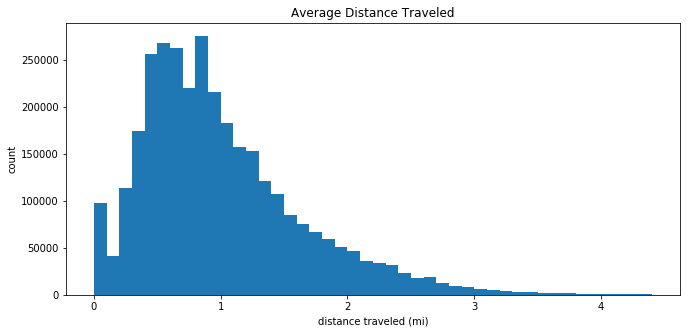

```python
plt.figure(figsize = (11,5))
bin_edges = np.arange(0, 4.5, .1);
plt.hist(df.distance, bins = bin_edges);
plt.xlabel('distance traveled (mi)');
plt.ylabel('count');
plt.title('Average Distance Traveled');
```

Some important points to take away:

- We have 2 spikes here. One at 0.0mi, makes sense, as many people return the bike to the same location they got it from. The second spike is around 0.8mi, which makes sense for people who likely rode from point A to point B.
- Data is right skewed
- How would this graph differ for different genders? Perhaps we can look at this in the bivariate distribution portion

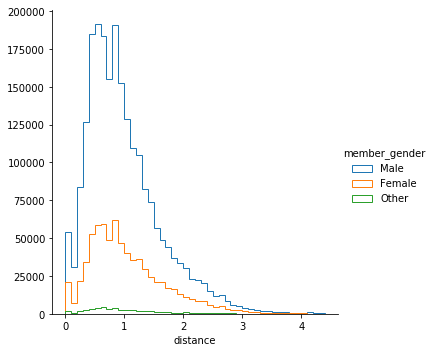

```python
bin_edges = np.arange(0, 4.5, .1)
g = sb.FacetGrid(data = df, hue = 'member_gender', size = 5);
g.map(plt.hist, "distance", bins = bin_edges, histtype = 'step');
g.add_legend();
```

> It looks as though the distribution of distance ridden by males and females is pretty similar so there isn't much of interesting going on here. Try investigating `user_type` to see if this differs. Perhaps another thing we can look at is the percentage of male vs female riders, as there appear to be way more male riders compared to female riders

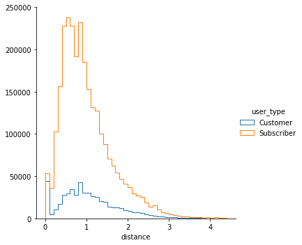

```python
bin_edges = np.arange(0, 4.5, .1)
g = sb.FacetGrid(data = df, hue = 'user_type', size = 5);
g.map(plt.hist, "distance", bins = bin_edges, histtype = 'step');
g.add_legend();
```

> It is slightly interesting to see that subscribers tend to ride about 1 mi, where as customers tend to ride the bike and return it to the same location (0 mi). Perhaps there is an additional fee here that customers do not need to pay?

### Exploring duration of each ride

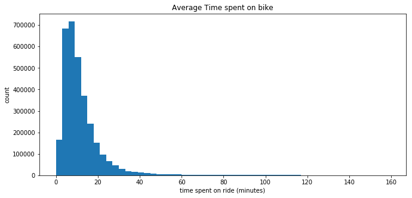

```python
plt.figure(figsize = (11,5))
bin_edges = np.arange(0, 162, 3);
plt.hist(df.duration_sec/60, bins = bin_edges);
plt.xlabel('time spent on ride (minutes)');
plt.ylabel('count');
plt.title('Average Time spent on bike');
```

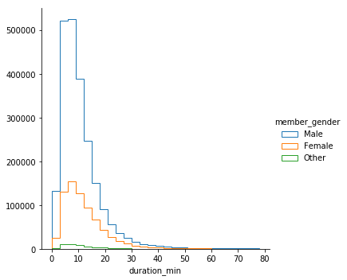

```python
df_2 = df.copy()
df_2['duration_min'] = df_2.duration_sec/60
bin_edges = np.arange(0, 80, 3)
g = sb.FacetGrid(data = df_2, hue = 'member_gender', size = 5);
g.map(plt.hist, "duration_min", bins = bin_edges, histtype = 'step');
g.add_legend();
```

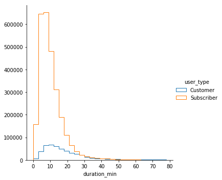

```python
bin_edges = np.arange(0, 80, 3)
g = sb.FacetGrid(data = df_2, hue = 'user_type', size = 5);
g.map(plt.hist, "duration_min", bins = bin_edges, histtype = 'step');
g.add_legend();
```

- Sadly nothing to really different between the patterns of the male and female users, and no real difference between the customers and subcribers in terms of time spent on the bike. It looks like the average time spent on the bike is ~10 minutes

### Look at the gender breakdown of users

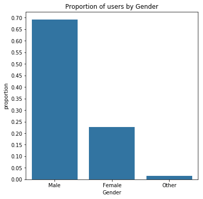

```python
plt.figure(figsize=(6,6))
base_color = sb.color_palette()[0]

# Will be used to plot relative frequency
n_points = df.shape[0]
max_count = df['member_gender'].value_counts().max()
max_prop = max_count / n_points

# generate tick mark locations and names
tick_props = np.arange(0, max_prop+.05, 0.05)
tick_names = ['{:0.2f}'.format(v) for v in tick_props]

sb.countplot(data = df, x = 'member_gender', color = base_color)
plt.yticks(tick_props * n_points, tick_names);
plt.ylabel('proportion');
plt.xlabel('Gender');
plt.title('Proportion of users by Gender');
```

```python
df['member_gender'].value_counts()/n_points
```

```
Male      0.691734
Female    0.226065
Other     0.015295
Name: member_gender, dtype: float64
```

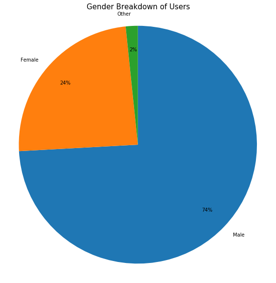

```python
sorted_counts = df['member_gender'].value_counts()
plt.figure(figsize = (20,10))
plt.pie(sorted_counts, labels = sorted_counts.index, startangle = 90,
        counterclock = False, autopct='%1.0f%%', pctdistance=.8);
plt.axis('square');
plt.title('Gender Breakdown of Users',fontsize=15);
```

- Nearly 3/4 of the users with a registered gender are male! Perhaps this is something FordGoBike's marketing team could look into

### Exploring gender vs subcription choice

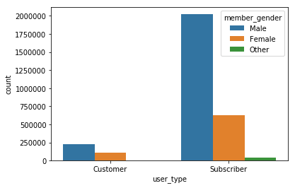

```python
sb.countplot(data = df, x = 'user_type', hue = 'member_gender');
```

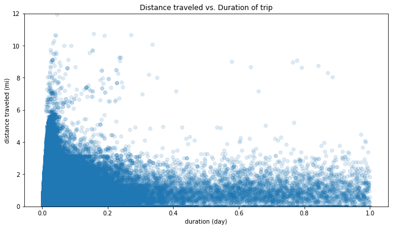

```python
#Scatter plot of dist vs. duration. Add in gender or member type to see if anything changes
df_3 = df_2.copy()
df_3['duration_day'] = df_2.duration_min/60/24

fig = plt.figure(figsize = (11,6))
ax = fig.add_subplot(111)
ax.scatter(data = df_3, x = 'duration_day',y = 'distance', alpha = 1/7);
ax.set_ylabel('distance traveled (mi)');
ax.set_xlabel('duration (day)');
ax.set_title('Distance traveled vs. Duration of trip');
ax.set_ylim(ymin=0.0, ymax=12);
```

- Interestingly we see that the maximum amount of time somebody takes a bike out for is approximately a day. However, having a bike for a longer period of time does not necessarily lead to longer trips as we can clearly see. It seems as though the longest trips come from those who had the bike for a few hours

### Look at the age breakdown of users in our data

- Start with the 2017 dataset, just to keep the size small

```python
# Look at average age of bike riders
df2017_age = df2017[df2017['member_birth_year'].isnull() == False].copy()
df2017_age['member_birth_year'] = df2017_age['member_birth_year'].astype(int)
BY_as_string17 = df2017_age['member_birth_year'].astype(str)
exact_ages17 = (df2017_age.start_time - pd.to_datetime(BY_as_string17))

ages17 = []
for i in exact_ages17:
    ages17.append((i.days)/365)
df2017_age['member_age'] = ages17
```

```python
df2017_age.head()
```

|  | duration_sec | start_time | end_time | start_station_id | start_station_name | start_station_latitude | start_station_longitude | end_station_id | end_station_name | end_station_latitude | end_station_longitude | bike_id | user_type | member_birth_year | member_gender | distance | member_age |
| --- | --- | --- | --- | --- | --- | --- | --- | --- | --- | --- | --- | --- | --- | --- | --- | --- | --- |
| 0 | 80110 | 2017-12-31 16:57:39.654 | 2018-01-01 15:12:50.245 | 74 | Laguna St at Hayes St | 37.776435 | -122.426244 | 43 | San Francisco Public Library (Grove St at Hyde... | 37.778768 | -122.415929 | 96 | Customer | 1987 | Male | 0.585910 | 31.019178 |
| 1 | 78800 | 2017-12-31 15:56:34.842 | 2018-01-01 13:49:55.617 | 284 | Yerba Buena Center for the Arts (Howard St at ... | 37.784872 | -122.400876 | 96 | Dolores St at 15th St | 37.766210 | -122.426614 | 88 | Customer | 1965 | Female | 1.907439 | 53.032877 |
| 4 | 43603 | 2017-12-31 14:23:14.001 | 2018-01-01 02:29:57.571 | 239 | Bancroft Way at Telegraph Ave | 37.868813 | -122.258764 | 247 | Fulton St at Bancroft Way | 37.867789 | -122.265896 | 3167 | Subscriber | 1997 | Female | 0.395403 | 21.010959 |
| 6 | 4507 | 2017-12-31 23:49:28.422 | 2018-01-01 01:04:35.619 | 259 | Addison St at Fourth St | 37.866249 | -122.299371 | 259 | Addison St at Fourth St | 37.866249 | -122.299371 | 3539 | Customer | 1991 | Female | 0.000000 | 27.016438 |
| 12 | 2183 | 2017-12-31 23:52:55.581 | 2018-01-01 00:29:18.743 | 67 | San Francisco Caltrain Station 2 (Townsend St... | 37.776639 | -122.395526 | 24 | Spear St at Folsom St | 37.789677 | -122.390428 | 2311 | Subscriber | 1990 | Male | 0.942836 | 28.016438 |

**Happened to notice a few anomallies upon my own investigation, see below**

```python
df2017_age.member_age.max()
```

```
131.7178082191781
```

```python
df2017_age[df2017_age.member_age == df2017_age.member_age.max()]
```

|  | duration_sec | start_time | end_time | start_station_id | start_station_name | start_station_latitude | start_station_longitude | end_station_id | end_station_name | end_station_latitude | end_station_longitude | bike_id | user_type | member_birth_year | member_gender | distance | member_age |
| --- | --- | --- | --- | --- | --- | --- | --- | --- | --- | --- | --- | --- | --- | --- | --- | --- | --- |
| 425817 | 2546 | 2017-08-19 17:47:32.110 | 2017-08-19 18:29:58.825 | 197 | El Embarcadero at Grand Ave | 37.808848 | -122.24968 | 172 | College Ave at Taft Ave | 37.841800 | -122.251535 | 1448 | Customer | 1886 | Male | 2.279012 | 131.717808 |
| 426608 | 1767 | 2017-08-19 13:20:02.170 | 2017-08-19 13:49:29.735 | 235 | Union St at 10th St | 37.807239 | -122.28937 | 197 | El Embarcadero at Grand Ave | 37.808848 | -122.249680 | 91 | Customer | 1886 | Male | 2.169482 | 131.717808 |

> Clearly it is very unlikely that this user was actually born in 1886 and is 131 years old. It is far more likely that he was born in 1986 and there was a typo. Given as this is the smaller dataset we are just using for investigation, we can ignore correcting for this error at the moment. We just need to remember to account for outliers when looking at the full dataset (df)
- Go through same process as above (to find member age) for the full dataset. Will likely take a long time to run through the next cell

```python
# Look at average age of bike riders
df_age = df[df['member_birth_year'].isnull() == False].copy()
df_age['member_birth_year'] = df_age['member_birth_year'].astype(int)
BY_as_string = df_age['member_birth_year'].astype(str)
exact_ages = (df_age.start_time - pd.to_datetime(BY_as_string))

ages = []
for i in exact_ages:
    ages.append((i.days)/365)
df_age['member_age'] = ages
```

```python
# Just checking that the above cell worked
df_age.head()
```

|  | bike_id | bike_share_for_all_trip | duration_sec | end_station_id | end_station_latitude | end_station_longitude | end_station_name | end_time | member_birth_year | member_gender | start_station_id | start_station_latitude | start_station_longitude | start_station_name | start_time | user_type | distance | member_age |
| --- | --- | --- | --- | --- | --- | --- | --- | --- | --- | --- | --- | --- | --- | --- | --- | --- | --- | --- |
| 0 | 96 | NaN | 80110 | 43.0 | 37.778768 | -122.415929 | San Francisco Public Library (Grove St at Hyde... | 2018-01-01 15:12:50.245 | 1987 | Male | 74.0 | 37.776435 | -122.426244 | Laguna St at Hayes St | 2017-12-31 16:57:39.654 | Customer | 0.585910 | 31.019178 |
| 1 | 88 | NaN | 78800 | 96.0 | 37.766210 | -122.426614 | Dolores St at 15th St | 2018-01-01 13:49:55.617 | 1965 | Female | 284.0 | 37.784872 | -122.400876 | Yerba Buena Center for the Arts (Howard St at ... | 2017-12-31 15:56:34.842 | Customer | 1.907439 | 53.032877 |
| 4 | 3167 | NaN | 43603 | 247.0 | 37.867789 | -122.265896 | Fulton St at Bancroft Way | 2018-01-01 02:29:57.571 | 1997 | Female | 239.0 | 37.868813 | -122.258764 | Bancroft Way at Telegraph Ave | 2017-12-31 14:23:14.001 | Subscriber | 0.395403 | 21.010959 |
| 6 | 3539 | NaN | 4507 | 259.0 | 37.866249 | -122.299371 | Addison St at Fourth St | 2018-01-01 01:04:35.619 | 1991 | Female | 259.0 | 37.866249 | -122.299371 | Addison St at Fourth St | 2017-12-31 23:49:28.422 | Customer | 0.000000 | 27.016438 |
| 12 | 2311 | NaN | 2183 | 24.0 | 37.789677 | -122.390428 | Spear St at Folsom St | 2018-01-01 00:29:18.743 | 1990 | Male | 67.0 | 37.776639 | -122.395526 | San Francisco Caltrain Station 2 (Townsend St... | 2017-12-31 23:52:55.581 | Subscriber | 0.942836 | 28.016438 |

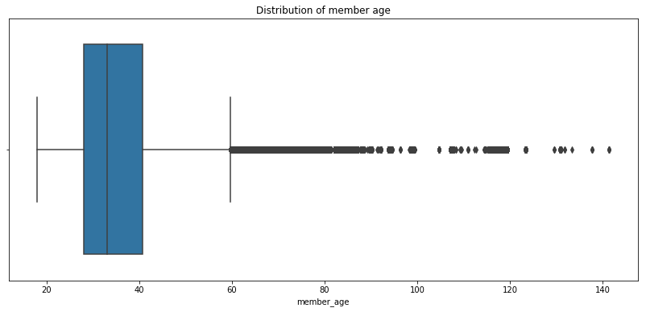

```python
plt.figure(figsize=(14,6))
sb.boxplot(x='member_age', data= df_age);
plt.title('Distribution of member age');
```

##### Let's sort these ages into bucks that we can look at as age demographics

```python
df_age.member_age.describe()
```

```
count    3.036159e+06
mean     3.548346e+01
std      1.038549e+01
min      1.803836e+01
25%      2.811507e+01
50%      3.312329e+01
75%      4.073425e+01
max      1.413726e+02
Name: member_age, dtype: float64
```

> We see that 50% of bikers fall between the ages of ~28 and ~41. We could divide these users into buckets based off of age and then see if we see any trends from the data based off of age

```python
# Bin ages into ranges
df_age['age_bins'] = df_age['member_age'].apply(lambda x: '<20' if x<20
                                                  else '20s' if 20<x<=30
                                                  else '30s' if 30<x<=40
                                                  else '40s' if 40<x<=50
                                                  else '50s' if 50<x<=60
                                                  else '>50')
```

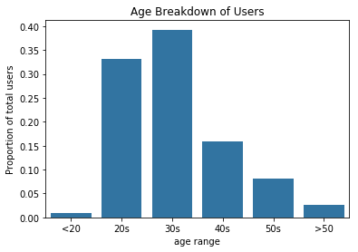

```python
# Will be used to plot relative frequency
n_points = df_age.shape[0]
max_count = df_age['age_bins'].value_counts().max()
max_prop = max_count / n_points

# generate tick mark locations and names
tick_props = np.arange(0, max_prop+.05, 0.05)
tick_names = ['{:0.2f}'.format(v) for v in tick_props]


base_color = sb.color_palette()[0]
cat_order = ['<20', '20s', '30s', '40s', '50s', '>50']
sb.countplot(data = df_age, x = 'age_bins', color = base_color, order = cat_order);

plt.yticks(tick_props * n_points, tick_names);
plt.title('Age Breakdown of Users');
plt.xlabel('age range');
plt.ylabel('Proportion of total users');
```

##### Those in their 30's tend to use the bike service the most. Let's see how the average distance per ride changes with these age groups

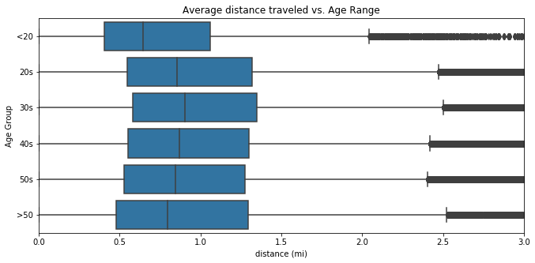

```python
base_color = sb.color_palette()[0]
plt.figure(figsize = (11,5))
sb.boxplot(data = df_age, x = 'distance', y = 'age_bins', color = base_color, order = cat_order)
plt.axis(xmin = 0, xmax = 3);
plt.xlabel('distance (mi)');
plt.ylabel('Age Group');
plt.title('Average distance traveled vs. Age Range');
```

- Not much to see here, maybe we could say that people in their 30s seem to have the longest avergage distance traveled by a slight margin
- lets see if the membership (customer vs subscriber varies with age)

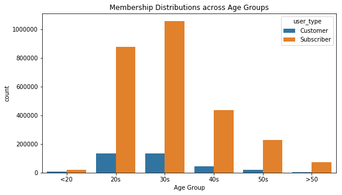

```python
plt.figure(figsize = (9,5))
sb.countplot(data = df_age, x = 'age_bins', hue = 'user_type', order = cat_order);
plt.xlabel('Age Group');
plt.title('Membership Distributions across Age Groups');
```

##### The ratio of customers to subscribers is higher the younger the age group! Perhaps marketing needs to target younger audiences to try and get subscribers

```python
# Look at average time of day that each bike ride is taken (scatter of time vs. duration)
time_of_day = []
for i in df.start_time:
    hour_min = float(i.hour)+ float(i.minute)/60
    time_of_day.append(hour_min)
```

```python
df['time_of_day'] = time_of_day
df.head()
```

|  | bike_id | bike_share_for_all_trip | duration_sec | end_station_id | end_station_latitude | end_station_longitude | end_station_name | end_time | member_birth_year | member_gender | start_station_id | start_station_latitude | start_station_longitude | start_station_name | start_time | user_type | distance | time_of_day |
| --- | --- | --- | --- | --- | --- | --- | --- | --- | --- | --- | --- | --- | --- | --- | --- | --- | --- | --- |
| 0 | 96 | NaN | 80110 | 43.0 | 37.778768 | -122.415929 | San Francisco Public Library (Grove St at Hyde... | 2018-01-01 15:12:50.245 | 1987.0 | Male | 74.0 | 37.776435 | -122.426244 | Laguna St at Hayes St | 2017-12-31 16:57:39.654 | Customer | 0.585910 | 16.950000 |
| 1 | 88 | NaN | 78800 | 96.0 | 37.766210 | -122.426614 | Dolores St at 15th St | 2018-01-01 13:49:55.617 | 1965.0 | Female | 284.0 | 37.784872 | -122.400876 | Yerba Buena Center for the Arts (Howard St at ... | 2017-12-31 15:56:34.842 | Customer | 1.907439 | 15.933333 |
| 2 | 1094 | NaN | 45768 | 245.0 | 37.870348 | -122.267764 | Downtown Berkeley BART | 2018-01-01 11:28:36.883 | NaN | NaN | 245.0 | 37.870348 | -122.267764 | Downtown Berkeley BART | 2017-12-31 22:45:48.411 | Customer | 0.000000 | 22.750000 |
| 3 | 2831 | NaN | 62172 | 5.0 | 37.783899 | -122.408445 | Powell St BART Station (Market St at 5th St) | 2018-01-01 10:47:23.531 | NaN | NaN | 60.0 | 37.774520 | -122.409449 | 8th St at Ringold St | 2017-12-31 17:31:10.636 | Customer | 0.650341 | 17.516667 |
| 4 | 3167 | NaN | 43603 | 247.0 | 37.867789 | -122.265896 | Fulton St at Bancroft Way | 2018-01-01 02:29:57.571 | 1997.0 | Female | 239.0 | 37.868813 | -122.258764 | Bancroft Way at Telegraph Ave | 2017-12-31 14:23:14.001 | Subscriber | 0.395403 | 14.383333 |

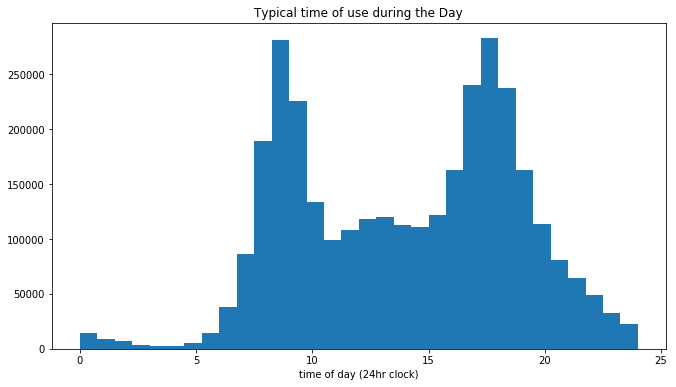

```python
plt.figure(figsize = (11,6))
bin_edges = np.arange(0, df.time_of_day.max()+.75, .75)
plt.hist(data = df, x = 'time_of_day', bins = bin_edges)
plt.xlabel('time of day (24hr clock)');
plt.title('Typical time of use during the Day');
```

> As we would expect this graph has two spikes located around 9am and 5pm, which would make sense during a regular work day for commuter hours

### How overall bike trend numbers have changed over time

> Track how the general numbers have changed by binning the time by months in the same way we binned the age. Then we can see how this has changed over time with by plotting these points in a line

```python
# Generating time bins which will be formatted 'm/y'
time_bin = []
for i in df_age.start_time:
    #year = i.year
    #month = i.month
    time_bin.append(str(i.month) + '/' + str(i.year%100))
```

```python
# Add time bin column to dataframe
df_age['time_bins'] = time_bin
```

```python
# Check to see that it worked
df_age.time_bins.value_counts()
```

```
3/19     244576
4/19     227912
10/18    192804
7/18     186793
6/18     183364
1/19     182362
8/18     181247
9/18     176303
2/19     175147
5/18     167376
11/18    129037
12/18    126352
4/18     121791
3/18     102347
2/18      98626
10/17     95316
1/18      86963
11/17     86090
9/17      85437
12/17     78236
8/17      69783
7/17      35910
6/17       2387
Name: time_bins, dtype: int64
```

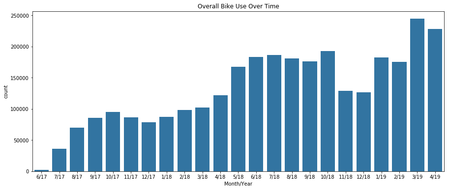

```python
# Plot histogram of use time
plt.figure(figsize = (15,6))
time_order = ['6/17', '7/17', '8/17', '9/17', '10/17', '11/17', '12/17', '1/18', '2/18', '3/18', '4/18'
             , '5/18', '6/18', '7/18', '8/18', '9/18', '10/18', '11/18', '12/18', '1/19', '2/19'
             , '3/19', '4/19']
sb.countplot(data = df_age, x = 'time_bins', color = base_color, order = time_order);
plt.xlabel('Month/Year');
plt.title('Overall Bike Use Over Time');
```

###### Thus we see an overall upwards trend! Business appears to be going well!

- Now lets try breaking this plot down into more subcategories. Let's first break it down by gender as another layer on top of this graph

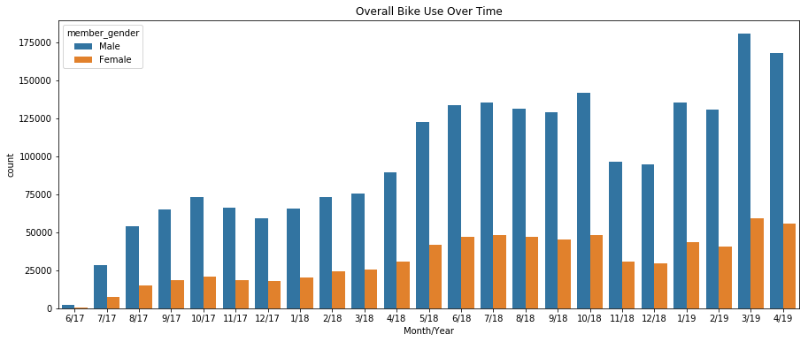

```python
# Plot histogram of use time with gender included
plt.figure(figsize = (15,6))
h_order = ['Male', 'Female']    # 'Other' was distracting in final plot, just look at men and women
sb.countplot(data = df_age, x = 'time_bins', hue = 'member_gender', order = time_order, hue_order = h_order);
plt.xlabel('Month/Year');
plt.title('Overall Bike Use Over Time');
```

##### General upward trend for both men and women

- Other was a bit hard to get a read on and my be distracting, thus it was taken out. Think changing y-axis to relative proportions for final cleaner plot
  - Look at `user_type` next

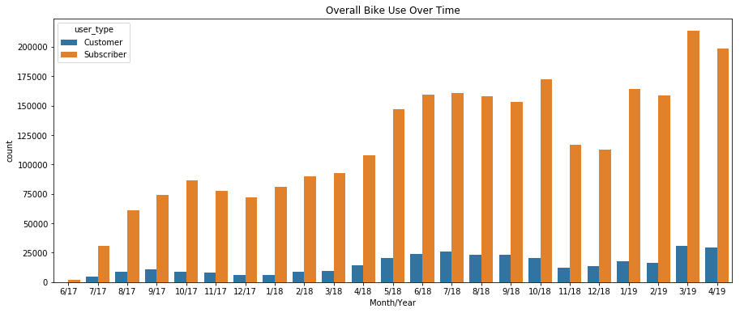

```python
# Plot histogram of use time with user type included
plt.figure(figsize = (15,6))
sb.countplot(data = df_age, x = 'time_bins', hue = 'user_type', order = time_order);
plt.xlabel('Month/Year');
plt.title('Overall Bike Use Over Time');
```

##### The subscriber ratings have also gone up over time! This is a good thing to see from a fordGoBike point of view

- Now lets try to look at a lone plot of age bin data and the bike use over time

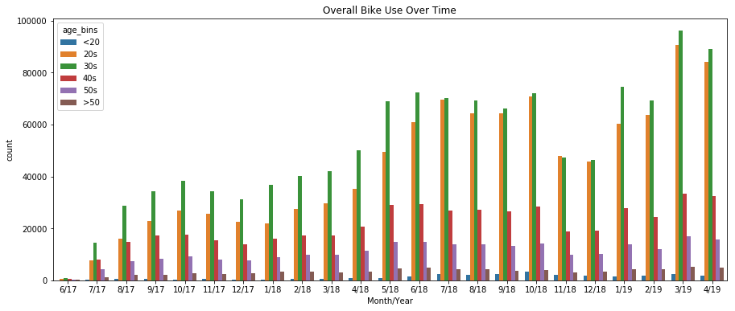

```python
plt.figure(figsize = (15,6))
sb.countplot(data = df_age, x = 'time_bins', hue = 'age_bins', order = time_order, hue_order = cat_order);
plt.xlabel('Month/Year');
plt.title('Overall Bike Use Over Time');
```

- This graph looks cluttered and gross, let's see if we can turn it into some sort of line plot using group by statements

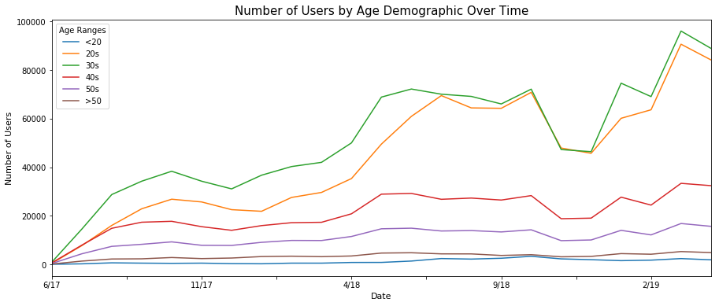

```python
# Creating a new datafram with groupedby results and plotting the trends over time
df_overtime = df_age.groupby('time_bins').age_bins.value_counts().unstack()
df_overtime = df_overtime.reindex(time_order)
df_overtime = df_overtime.reindex(columns=cat_order)
df_overtime.plot(figsize = (15,6));
plt.xlabel('Date', size = 11);
plt.ylabel('Number of Users', size = 11);
plt.title('Number of Users by Age Demographic Over Time', size = 15);
plt.legend(title = 'Age Ranges');
```

##### Thus we see a general upward trend over time, particularly for those in the 20s, 30s and 40s! The other age ranges seem to have been pretty consistent over the last couple of years

### Heat map of start_locaion vs. end location. Add in membership vs customer as third layer eventually

> We hope to see a trend for either starting or end locations (or both). This would shed some light onto what the bikes are most commonly used for

```python
latmin = df2017.start_station_latitude.min()
latmax = df2017.start_station_latitude.max()
lonmin = df2017.start_station_longitude.min()
lonmax = df2017.start_station_longitude.max()
latmin
```

```
37.3172979
```

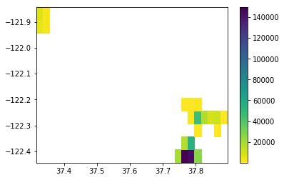

```python
bins_x = np.arange(latmin, latmax+.02, .02)
bins_y = np.arange(lonmin, lonmax+.05, .05)
plt.hist2d(data = df2017, x = 'start_station_latitude', y = 'start_station_longitude',
           bins = [bins_x, bins_y], cmap = 'viridis_r', cmin = 0.5);
plt.colorbar()
```

> After doing some googling it appears that the upper left corner is near San Jose while the lower right is San Francisco. San Francisco seems to have most of the data from this data set so lets just zoom in on this area. We can also now use the full dataset know that we know what we are doing/ where we are looking
- latmin = 37.725
- latmax = (same)
- lonmin = (same)
- lonmax = -122.25

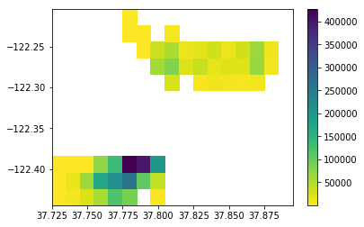

```python
bins_x = np.arange(37.725, latmax+.02, .01)
bins_y = np.arange(lonmin, -122.20, .02)
plt.hist2d(data = df, x = 'start_station_latitude', y = 'start_station_longitude',
           bins = [bins_x, bins_y], cmap = 'viridis_r', cmin = 0.5);
plt.colorbar();
```

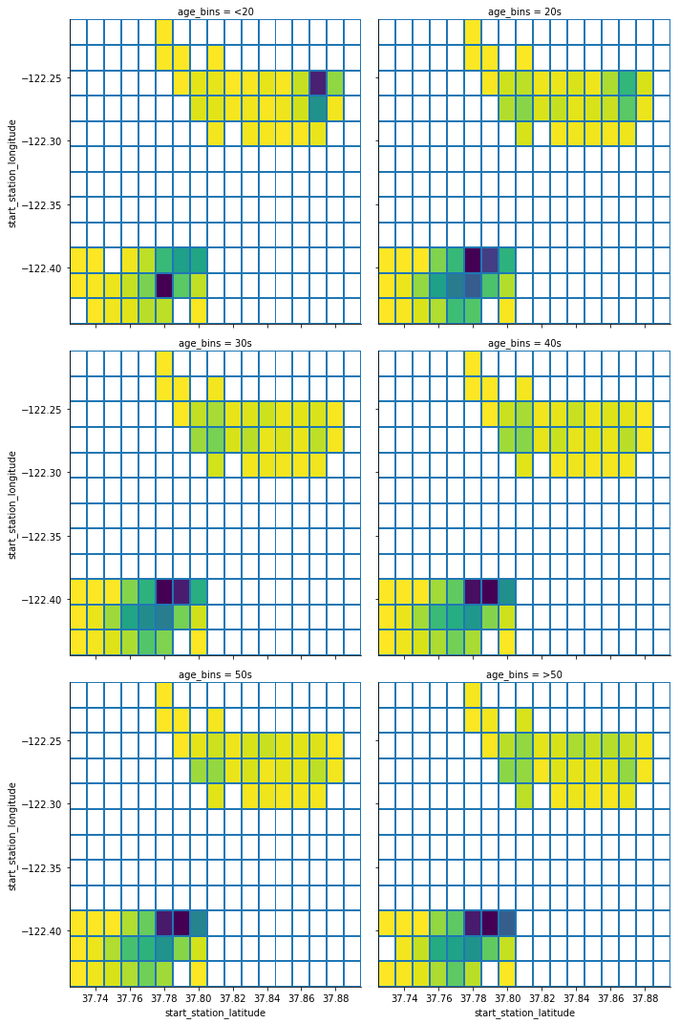

```python
g = sb.FacetGrid(data = df_age, col = 'age_bins', col_wrap = 2, size = 5, col_order = cat_order)
g.map(plt.hist2d, 'start_station_latitude', 'start_station_longitude',bins = [bins_x, bins_y], cmap = 'viridis_r', cmin = 0.5);
#plt.colorbar();
```

- We see that the most common starting point, across all age groups seems to be near ~(37.78,-122.39). Putting this into a map, we see that this is near the end of the Caltrain Stop in San Francisco (Caltrain one of the main commuter trains taken in the bay area). This supports our graph that showed that the peak riding times were during commuter hours
- Now lets look into a few more things using this same heat map idea
  - Are they all heading to a similar area of sf, or does this differ by user age?
  - Does these trends differ for subsribers vs. customers?

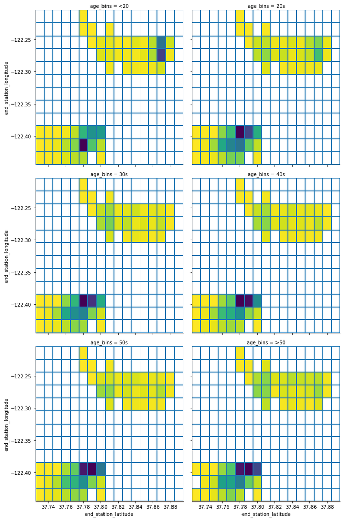

```python
g1 = sb.FacetGrid(data = df_age, col = 'age_bins', col_wrap = 2, size = 5, col_order = cat_order)
g1.map(plt.hist2d, 'end_station_latitude', 'end_station_longitude',bins = [bins_x, bins_y], cmap = 'viridis_r', cmin = 0.5);
```

Not enough granularity to see any changes here. We would have to zoom in on the caltrain stop, but we may not get much out of that. Let's look and see if this differs between customers and users

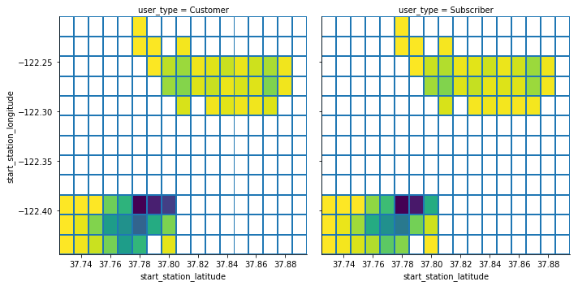

```python
g2 = sb.FacetGrid(data = df_age, col = 'user_type', col_wrap = 2, size = 5)
g2.map(plt.hist2d, 'start_station_latitude', 'start_station_longitude',bins = [bins_x, bins_y], cmap = 'viridis_r', cmin = 0.5);
```

Not much to see either. Whether they are a customer or a user they both seem to use it in the same fashion. Maybe try gender?

- Important note: the heat maps do not have the same colorbar ranking in the image above, as we know from previous plots that there were many more subscribers than customers

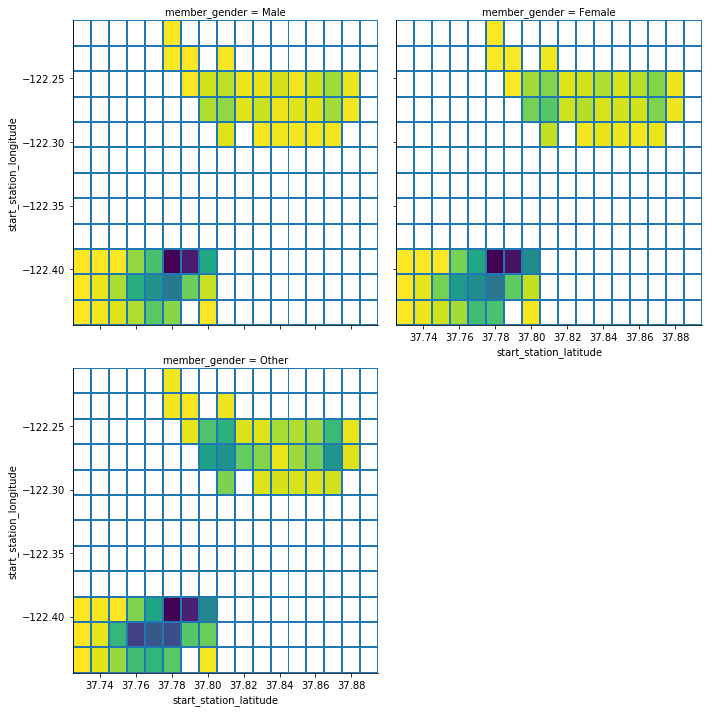

```python
g3 = sb.FacetGrid(data = df_age, col = 'member_gender', col_wrap = 2, size = 5)
g3.map(plt.hist2d, 'start_station_latitude', 'start_station_longitude',bins = [bins_x, bins_y], cmap = 'viridis_r', cmin = 0.5);
```

Not much to see here either

> The main take away from this heat map shows that the most common place to start/end a journey is near this Caltrain stop. This makes sense as people would seem to either bike to the Caltrain stop and then train to work, or take the Caltrain to San Francisco and then start their bike journey from there. Thus we have further evidence that most of the users are using the bikes for commuting purposes

#### Over the course of the exploratory analysis shown above, we came up with a few visualizations that were very insightful. Now we can clean those plots up and portray them in a way that conveys a message in a clear way. This will all be done in the Explanatory Visualization Shown Below

# Explanatory Visualization

> In this section I will pose questions, follow them up with just a graph or visual solution that portrays the answer to the associated question in a clear and effective way. For all of these plots I have chosen to ignore the `other` category because there isn't much information contained in this categrory and for my visualizations it is largely just cluttering up the plot

##### What is the gender breakdown of Users from the data?

We can see the gender breakdown of our users using a simple bar chart plot of our data. We find that GoBike users are predominantly male, with 69.2% of all users registering as male, while only 22.6% registered as female. There was also a small percentage that identified as 'Other' and many users that did not put down their gender. Out of only the users that filled out their gender information, 74% were men, 24% were women, and 2% identified as other.

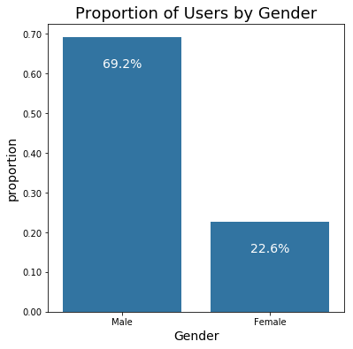

```python
plt.figure(figsize=(6,6))
base_color = sb.color_palette()[0]

# Will be used to plot relative frequency
n_points = df.shape[0]
max_count = df['member_gender'].value_counts().max()
max_prop = max_count / n_points

# generate tick mark locations and names
tick_props = np.arange(0, max_prop+.1, 0.1)
tick_names = ['{:0.2f}'.format(v) for v in tick_props]

sb.countplot(data = df, x = 'member_gender', color = base_color, order = ['Male', 'Female'])
plt.yticks(tick_props * n_points, tick_names);
plt.ylabel('proportion', size = 14);
plt.xlabel('Gender', size = 14);
plt.title('Proportion of Users by Gender', size = 18);

# add annotations
cat_counts_gender = df['member_gender'].value_counts()
locs, labels = plt.xticks() # get the current tick locations and labels

# loop through each pair of locations and labels
for loc, label in zip(locs, labels):

    # get the text property for the label to get the correct count
    count = cat_counts_gender[label.get_text()]
    pct_string = '{:0.1f}%'.format(100*count/n_points)

    # print the annotation just below the top of the bar
    plt.text(loc, count-250000, pct_string, ha = 'center', color = 'w', size =14)
```

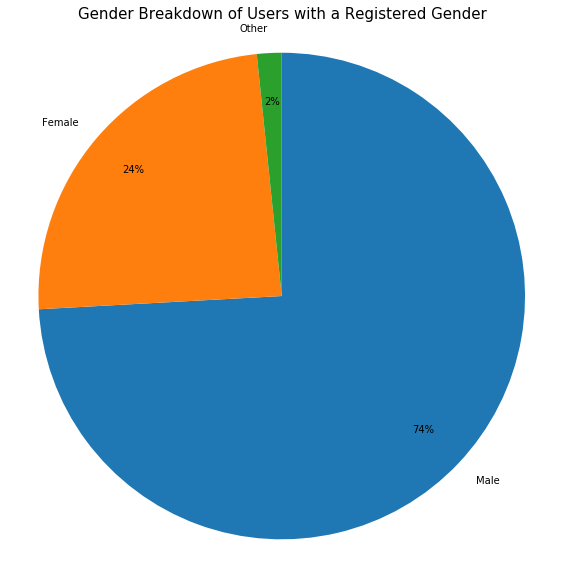

```python
sorted_counts = df['member_gender'].value_counts()
plt.figure(figsize = (20,10))
plt.pie(sorted_counts, labels = sorted_counts.index, startangle = 90,
        counterclock = False, autopct='%1.0f%%', pctdistance=.8);
plt.axis('square');
plt.title('Gender Breakdown of Users with a Registered Gender',fontsize=15);
```

##### What does the member vs. customer breakdown looklike?

Here we want to look at how many of the users are subscribers vs how many use the app as simply a customer. Once again a simple bar chart will suffice, and I also broke down the membership by gender to see any trends there. 84.4% of the users are subscribers while only 15.6% of the users are customers. The ratio of customers to subscribers is also much higher for females than it is for males

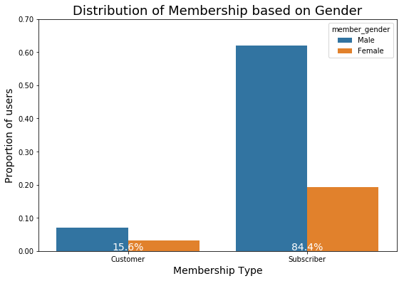

```python
plt.figure(figsize=(9,6));
sb.countplot(data = df, x = 'user_type', hue = 'member_gender', hue_order = ['Male', 'Female']);
plt.xlabel('Membership Type', size = 14);
plt.ylabel('Proportion of users', size = 14);
plt.title('Distribution of Membership based on Gender', size = 18);
plt.yticks(tick_props * n_points, tick_names);

# add annotations
cat_counts_user = df['user_type'].value_counts()
locs1, labels1 = plt.xticks() # get the current tick locations and labels

# loop through each pair of locations and labels
for loc, label in zip(locs1, labels1):

    # get the text property for the label to get the correct count
    count = cat_counts_user[label.get_text()]
    pct_string = '{:0.1f}%'.format(100*count/n_points)

    # print the annotation just below the top of the bar
    plt.text(loc, 10000, pct_string, ha = 'center', color = 'w', size =14)
```

##### What is the most common distance traveled per trip? (include gender/member breakdown in graph)

We can see how far the average user goes on a ride by plotting a histogram of the data. We also broke this down by gender and membership type to see if these factors had any effect on the distance traveled. In the end the most common trip length is about 0.5 to 0.6 miles and this did not vary based off of gender. However, for customers, the most common ride involved returning the bike to the same location, thus giving an effective total distance traveled of 0.0 miles.

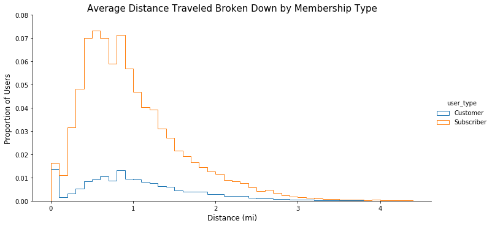

```python
# Will be used to plot relative frequency
n_points = df.shape[0]
max_count = df[(df['distance'] < .6) & (df['distance'] >= .5)]['user_type'].value_counts().max() #Found from determining which bucket gives us the max
max_prop = max_count / n_points

# generate tick mark locations and names
tick_props = np.arange(0, max_prop+.01, 0.01)
tick_names = ['{:0.2f}'.format(v) for v in tick_props]

# Plotting DIstance Traveled against Membership Type
bin_edges = np.arange(0, 4.5, .1)
g = sb.FacetGrid(data = df, hue = 'user_type', size = 5, aspect = 2);
g.map(plt.hist, "distance", bins = bin_edges, histtype = 'step');
g.add_legend();
plt.title('Average Distance Traveled Broken Down by Membership Type', size = 15);
plt.xlabel('Distance (mi)', size = 12);
plt.ylabel('Proportion of Users', size = 12);
plt.yticks(tick_props * n_points, tick_names);
```

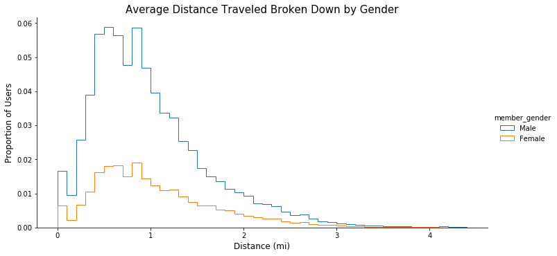

```python
# Will be used to plot relative frequency
n_points = df.shape[0]
max_count = df[(df['distance'] < .6) & (df['distance'] >= .5)]['member_gender'].value_counts().max() #Found from determining which bucket gives us the max
max_prop = max_count / n_points

# generate tick mark locations and names
tick_props = np.arange(0, max_prop+.01, 0.01)
tick_names = ['{:0.2f}'.format(v) for v in tick_props]

# Plotting DIstance Traveled against Membership Type
bin_edges = np.arange(0, 4.5, .1)
g = sb.FacetGrid(data = df, hue = 'member_gender', size = 5, aspect = 2, hue_order = ['Male','Female']);
g.map(plt.hist, "distance", bins = bin_edges, histtype = 'step');
g.add_legend();
plt.title('Average Distance Traveled Broken Down by Gender', size = 15);
plt.xlabel('Distance (mi)', size = 12);
plt.ylabel('Proportion of Users', size = 12);
plt.yticks(tick_props * n_points, tick_names);
```

##### What about the average duration of a trip? (include gender/member breakdown in graph)

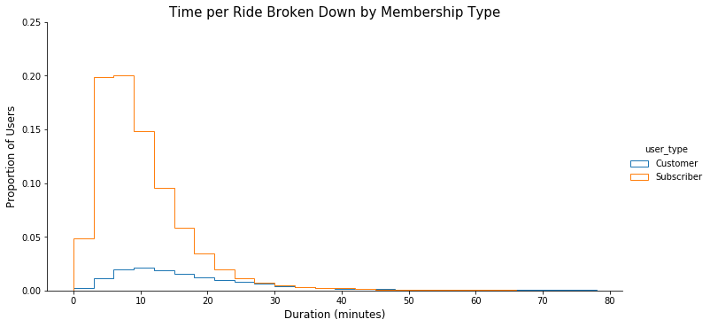

```python
# Will be used to plot relative frequency
n_points = df_2.shape[0]
max_count = df_2[(df_2['duration_min'] < 9) & (df_2['duration_min'] >= 6)]['user_type'].value_counts().max() #Found from determining which bucket gives us the max
max_prop = max_count / n_points

# generate tick mark locations and names
tick_props = np.arange(0, max_prop+.05, 0.05)
tick_names = ['{:0.2f}'.format(v) for v in tick_props]

# Plotting DIstance Traveled against Membership Type
bin_edges = np.arange(0, 80, 3)
g = sb.FacetGrid(data = df_2, hue = 'user_type', size = 5, aspect = 2);
g.map(plt.hist, "duration_min", bins = bin_edges, histtype = 'step');
g.add_legend();
plt.title('Time per Ride Broken Down by Membership Type', size = 15);
plt.xlabel('Duration (minutes)', size = 12);
plt.ylabel('Proportion of Users', size = 12);
plt.yticks(tick_props * n_points, tick_names);
```

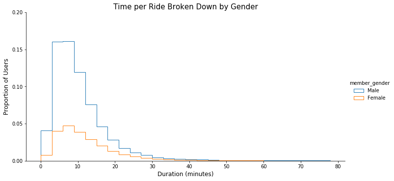

```python
# Will be used to plot relative frequency
n_points = df_2.shape[0]
max_count = df_2[(df_2['duration_min'] < 9) & (df_2['duration_min'] >= 6)]['member_gender'].value_counts().max() #Found from determining which bucket gives us the max
max_prop = max_count / n_points

# generate tick mark locations and names
tick_props = np.arange(0, max_prop+.05, 0.05)
tick_names = ['{:0.2f}'.format(v) for v in tick_props]

# Plotting DIstance Traveled against Membership Type
bin_edges = np.arange(0, 80, 3)
g = sb.FacetGrid(data = df_2, hue = 'member_gender', size = 5, aspect = 2, hue_order = ['Male', 'Female']);
g.map(plt.hist, "duration_min", bins = bin_edges, histtype = 'step');
g.add_legend();
plt.title('Time per Ride Broken Down by Gender', size = 15);
plt.xlabel('Duration (minutes)', size = 12);
plt.ylabel('Proportion of Users', size = 12);
plt.yticks(tick_props * n_points, tick_names);
```

##### What does the age breakdown of our users look like? Does age effect whether or not they are a member/how far a user is willing to travel?

In order to get a read on this, I binned all the users with a registered age into an age category, each separated by a decade (<20 years old, between 20-30 years old, between 30-40 years old, etc). Then I simply tallied up the total counts for these stats and plotted the results in a bar chart. It can be seen from the plot that people in their 20's and 30's are the biggest users in terms of age range for this app

I then went on to see if this age range affected distance traveled but there was not much difference in this between the age groups. The results are shown as a clustered box plot, and you can see that most age ranges have approximately the same median distance traveled per ride. However, users in the 30s seem to travel slightly further on average compared to the other age roups.

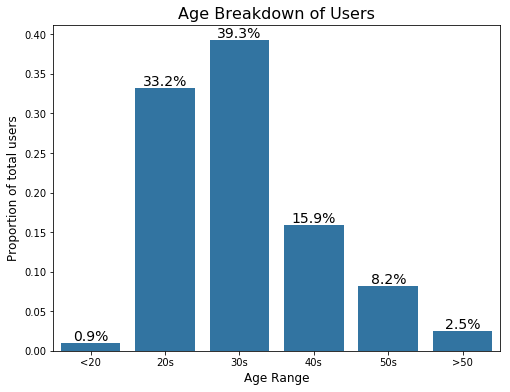

```python
# Will be used to plot relative frequency
n_points = df_age.shape[0]
max_count = df_age['age_bins'].value_counts().max()
max_prop = max_count / n_points

# generate tick mark locations and names
tick_props = np.arange(0, max_prop+.05, 0.05)
tick_names = ['{:0.2f}'.format(v) for v in tick_props]


base_color = sb.color_palette()[0]
cat_order = ['<20', '20s', '30s', '40s', '50s', '>50']
plt.figure(figsize = (8,6))
sb.countplot(data = df_age, x = 'age_bins', color = base_color, order = cat_order);

plt.yticks(tick_props * n_points, tick_names);
plt.title('Age Breakdown of Users', size = 16);
plt.xlabel('Age Range', size = 12);
plt.ylabel('Proportion of total users', size = 12);

# add annotations
cat_counts_age = df_age['age_bins'].value_counts()
locs_age, labels_age = plt.xticks() # get the current tick locations and labels

# loop through each pair of locations and labels
for loc, label in zip(locs_age, labels_age):

    # get the text property for the label to get the correct count
    count = cat_counts_age[label.get_text()]
    pct_string = '{:0.1f}%'.format(100*count/n_points)

    # print the annotation just below the top of the bar
    plt.text(loc, count+10000, pct_string, ha = 'center', color = 'black', size =14)
```

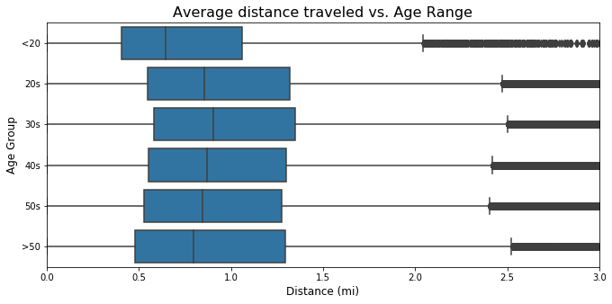

```python
base_color = sb.color_palette()[0]
plt.figure(figsize = (11,5))
sb.boxplot(data = df_age, x = 'distance', y = 'age_bins', color = base_color, order = cat_order)
plt.axis(xmin = 0, xmax = 3);
plt.xlabel('Distance (mi)', size =12);
plt.ylabel('Age Group', size = 12);
plt.title('Average distance traveled vs. Age Range', size = 16);
```

##### What time of day do users most commly use the bikes?

To figure this out I plotted a histogram of the start time of each ride. It appears as though the result is bimodal, with the two peaks coming at either side of rush hour (around 9am and around 5-6pm)

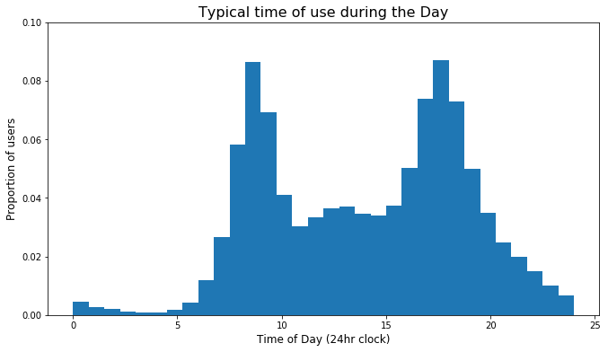

```python
# Will be used to plot relative frequency
n_points = df.shape[0]
max_count = df[(df['time_of_day'] < 9) & (df['time_of_day'] >= 8.25)].shape[0]
max_prop = max_count / n_points

# generate tick mark locations and names
tick_props = np.arange(0, max_prop+.02, .02)
tick_names = ['{:0.2f}'.format(v) for v in tick_props]

plt.figure(figsize = (11,6))
bin_edges = np.arange(0, df.time_of_day.max()+.75, .75)
plt.hist(data = df, x = 'time_of_day', bins = bin_edges)
plt.xlabel('Time of Day (24hr clock)',size = 12);
plt.ylabel('Proportion of users',size = 12);
plt.title('Typical time of use during the Day',size = 16);
plt.yticks(tick_props * n_points, tick_names);
```

##### Where do most of the journeys start/end from or is it more uniform? Does it differ by age/gender/membership?

To answer this question I plotted a heat map of longitude vs. latitude for all the rides in the data set. There appeared to be one central hotspot, located near the financial district and the Caltrain stop in San Francisco. There are many people that take Caltrain to work everyday, which further supports the idea that users use the GoBike as a commuting tool.

Surprisingly the heat map that included every registered ride, regardless of age/gender/membership/or even whether it was starting or ending a trip, all looked very similar. Thus rather than show a cluttered plot, I will just show one map containing all the data, as it is pretty consistent across the board.

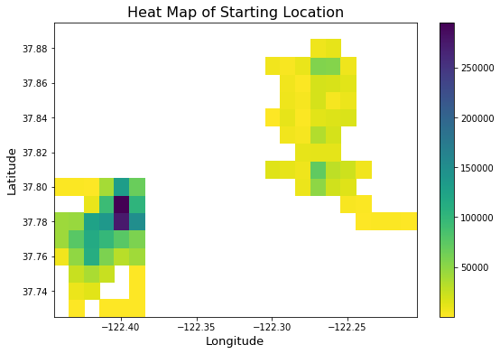

```python
bins_y = np.arange(37.725, latmax+.02, .01)
bins_x = np.arange(lonmin, -122.20, .01)
plt.figure(figsize = (9,6));
plt.hist2d(data = df, y = 'start_station_latitude', x = 'start_station_longitude',
           bins = [bins_x, bins_y], cmap = 'viridis_r', cmin = 0.5);
plt.colorbar();
plt.ylabel('Latitude', size = 13);
plt.xlabel('Longitude', size = 13);
plt.title('Heat Map of Starting Location', size = 16);
```

##### How has the overall usage of bikes changed over time?

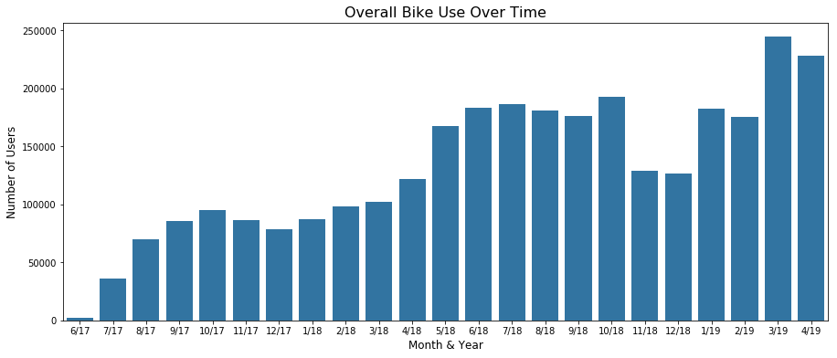

```python
# Plot histogram of use time
plt.figure(figsize = (15,6))
time_order = ['6/17', '7/17', '8/17', '9/17', '10/17', '11/17', '12/17', '1/18', '2/18', '3/18', '4/18'
             , '5/18', '6/18', '7/18', '8/18', '9/18', '10/18', '11/18', '12/18', '1/19', '2/19'
             , '3/19', '4/19']
sb.countplot(data = df_age, x = 'time_bins', color = base_color, order = time_order);
plt.xlabel('Month & Year', size = 12);
plt.ylabel('Number of Users', size = 12)
plt.title('Overall Bike Use Over Time', size = 16);
```

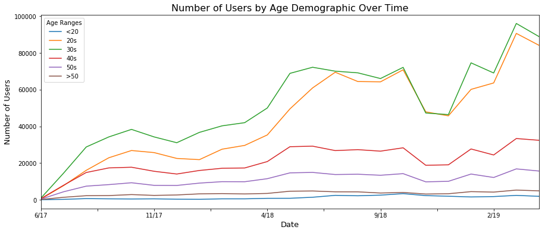

```python
# Creating a new dataframe with groupedby results and plotting the trends over time
df_overtime = df_age.groupby('time_bins').age_bins.value_counts().unstack()
df_overtime = df_overtime.reindex(time_order)
df_overtime = df_overtime.reindex(columns=cat_order)
df_overtime.plot(figsize = (15,6));
plt.xlabel('Date', size = 13);
plt.ylabel('Number of Users', size = 13);
plt.title('Number of Users by Age Demographic Over Time', size = 16);
plt.legend(title = 'Age Ranges');
```

# Conclusion

> Through this project we were able to explore Ford-Go-Bike Data over the last couple years and make visualizations to depict what we see through our exploratory analysis. The data first had to be stored in a central data frame, and this was relatively easy as all the information was in one location and the data was relatively clean to begin with. I then explored the data and looked for trends and saw if I could portray this information in a nice visual way

Some key points seen:

- 69.2% of the users are registered as males and 22.6% are registered as females. Clearly a male dominated app. If we just look at the users with registered genders the breakdown is 74% male and 24% female.
- 84.4% of the users are subscribers to the app while only 15.6% of users are customers
- Looking at the heat map and the peak time for rides during the day, we can infer that the Ford GoBike is used predominantly used by commuters. Most bike rides come around 9am and 6pm which are usual commuter times, and many rides start/end in the financial district of SF or the Caltrain stop, which adds more evidence to support the commuter claim
- Most of the users are in their 20s and 30s, with those age ranges occupying 33.2% and 39.3% of the users that input their age information
- The overall usage of bikes has gone up over the last 2 years, with over 5 times as many users in April 2019 compared to July of 2017. This increase in users largely comes from an increase in users in their 20s, 30s, and 40s. All other age demographics have maintained a relatively constant number of users per month over the last 2 years